# Легиньких_Лабораторная_6

### РОССИЙСКИЙ УНИВЕРСИТЕТ ДРУЖБЫ НАРОДОВ

#### Факультет физико-математических и естественных наук

#### Кафедра математического моделирования и искусственного интеллекта

## ОТЧЕТ ПО ЛАБОРАТОРНОЙ РАБОТЕ № 6

#### Дисциплина: Интеллектуальный анализ данных

##### Студент: Легиньких Галина

##### Группа: НФИбд-02-21

##### Москва 2024

### Вариант № 6 (Wine Data Set)

Название файла: wine.data

Класс: cultivar (столбец No 1)

Метод обработки пропущенных значений – медиана признака

Метод нормализации признаков – стандартизация

Алгоритм снижения размерности данных – рекурсивное исключение признаков (RFE)

Дополнительные базовые классификаторы:

классификатор логистической регрессии с полиномиальной зависимостью (degree=2)

классификатор метода опорных векторов

Комбинированный классификатор: VotingClassifier

Ансамблевые классификаторы: RandomForestClassifier, GradientBoostingClassifier

Показатель качества модели – доля верных ответов (accuracy)

## Выполнение

1. Считайте заданный набор данных из репозитария UCI, включая указанный в индивидуальном задании столбец с метками классов.

Считала данные.

```python
import pandas as pd

url = \
    "https://archive.ics.uci.edu/ml/"+\
    "machine-learning-databases/wine/wine.data"

wine = pd.read_csv(url, header=None)
wine.columns = ['Cultivar', 'Alcohol', 'Malic acid', 'Ash', 'Alcalinity of ash',  'Magnesium', 'Total phenols',
				'Flavanoids', 'Nonflavanoid phenols', 'Proanthocyanins',  'Color intensity', 'Hue',
				'OD280/OD315 of diluted wines', 'Proline']
wine
```

|  | Cultivar | Alcohol | Malic acid | Ash | Alcalinity of ash | Magnesium | Total phenols | Flavanoids | Nonflavanoid phenols | Proanthocyanins | Color intensity | Hue | OD280/OD315 of diluted wines | Proline |
| --- | --- | --- | --- | --- | --- | --- | --- | --- | --- | --- | --- | --- | --- | --- |
| 0 | 1 | 14.23 | 1.71 | 2.43 | 15.6 | 127 | 2.80 | 3.06 | 0.28 | 2.29 | 5.64 | 1.04 | 3.92 | 1065 |
| 1 | 1 | 13.20 | 1.78 | 2.14 | 11.2 | 100 | 2.65 | 2.76 | 0.26 | 1.28 | 4.38 | 1.05 | 3.40 | 1050 |
| 2 | 1 | 13.16 | 2.36 | 2.67 | 18.6 | 101 | 2.80 | 3.24 | 0.30 | 2.81 | 5.68 | 1.03 | 3.17 | 1185 |
| 3 | 1 | 14.37 | 1.95 | 2.50 | 16.8 | 113 | 3.85 | 3.49 | 0.24 | 2.18 | 7.80 | 0.86 | 3.45 | 1480 |
| 4 | 1 | 13.24 | 2.59 | 2.87 | 21.0 | 118 | 2.80 | 2.69 | 0.39 | 1.82 | 4.32 | 1.04 | 2.93 | 735 |
| ... | ... | ... | ... | ... | ... | ... | ... | ... | ... | ... | ... | ... | ... | ... |
| 173 | 3 | 13.71 | 5.65 | 2.45 | 20.5 | 95 | 1.68 | 0.61 | 0.52 | 1.06 | 7.70 | 0.64 | 1.74 | 740 |
| 174 | 3 | 13.40 | 3.91 | 2.48 | 23.0 | 102 | 1.80 | 0.75 | 0.43 | 1.41 | 7.30 | 0.70 | 1.56 | 750 |
| 175 | 3 | 13.27 | 4.28 | 2.26 | 20.0 | 120 | 1.59 | 0.69 | 0.43 | 1.35 | 10.20 | 0.59 | 1.56 | 835 |
| 176 | 3 | 13.17 | 2.59 | 2.37 | 20.0 | 120 | 1.65 | 0.68 | 0.53 | 1.46 | 9.30 | 0.60 | 1.62 | 840 |
| 177 | 3 | 14.13 | 4.10 | 2.74 | 24.5 | 96 | 2.05 | 0.76 | 0.56 | 1.35 | 9.20 | 0.61 | 1.60 | 560 |

178 rows × 14 columns

2. Если среди меток класса имеются пропущенные значения, то удалите записи с пропущенными метками класса. Преобразуйте категориальные признаки в числовые при помощи кодирования меток (label encoding). Если в признаках имеются пропущенные значения, то замените пропущенные значения, используя метод, указанный в индивидуальном задании. Если в признаках пропущенных значений нет, то удалите из набора данных записи, идентифицированные как выбросы при помощи метода кластеризации DBSCAN.

Среди меток класса нет пропущенных значений. Среди признаков тоже.

```python
import numpy as np

wine = wine.replace('?', np.NaN) # заменим '?' на np.NaN

print('Число пропущенных значений:')
for col in wine.columns:
    print("NaN in", col,"=", wine[col].isna().sum())
```

```
Число пропущенных значений:
NaN in Cultivar = 0
NaN in Alcohol = 0
NaN in Malic acid = 0
NaN in Ash = 0
NaN in Alcalinity of ash = 0
NaN in Magnesium = 0
NaN in Total phenols = 0
NaN in Flavanoids = 0
NaN in Nonflavanoid phenols = 0
NaN in Proanthocyanins = 0
NaN in Color intensity = 0
NaN in Hue = 0
NaN in OD280/OD315 of diluted wines = 0
NaN in Proline = 0
```

Все признаки числовые.

```python
wine.dtypes
```

```
Cultivar                          int64
Alcohol                         float64
Malic acid                      float64
Ash                             float64
Alcalinity of ash               float64
Magnesium                         int64
Total phenols                   float64
Flavanoids                      float64
Nonflavanoid phenols            float64
Proanthocyanins                 float64
Color intensity                 float64
Hue                             float64
OD280/OD315 of diluted wines    float64
Proline                           int64
dtype: object
```

Удалила из набора данных записи, идентифицированные как выбросы при помощи метода кластеризации DBSCAN. Решила настроить параметры так: eps = 3, min_samples=3. В принципе, можно было подобрать другие. Так же для этого метода нужно было нормализовать данные, так как у всех параметров разный диапазон (метод стандартизации)

```python
from sklearn.preprocessing import StandardScaler
from sklearn.cluster import DBSCAN

features = wine.drop('Cultivar', axis=1)

# Стандартизация данных
scaler = StandardScaler()
features_scaled = scaler.fit_transform(features)

# Применяем DBSCAN
dbscan = DBSCAN(eps=3, min_samples=3)
clusters = dbscan.fit_predict(features_scaled)

wine['Cluster'] = clusters
wine_new = wine[wine['Cluster'] != -1].drop(columns='Cluster')
wine_new = wine_new.reset_index(drop=True)
wine_new
```

|  | Cultivar | Alcohol | Malic acid | Ash | Alcalinity of ash | Magnesium | Total phenols | Flavanoids | Nonflavanoid phenols | Proanthocyanins | Color intensity | Hue | OD280/OD315 of diluted wines | Proline |
| --- | --- | --- | --- | --- | --- | --- | --- | --- | --- | --- | --- | --- | --- | --- |
| 0 | 1 | 14.23 | 1.71 | 2.43 | 15.6 | 127 | 2.80 | 3.06 | 0.28 | 2.29 | 5.64 | 1.04 | 3.92 | 1065 |
| 1 | 1 | 13.20 | 1.78 | 2.14 | 11.2 | 100 | 2.65 | 2.76 | 0.26 | 1.28 | 4.38 | 1.05 | 3.40 | 1050 |
| 2 | 1 | 13.16 | 2.36 | 2.67 | 18.6 | 101 | 2.80 | 3.24 | 0.30 | 2.81 | 5.68 | 1.03 | 3.17 | 1185 |
| 3 | 1 | 14.37 | 1.95 | 2.50 | 16.8 | 113 | 3.85 | 3.49 | 0.24 | 2.18 | 7.80 | 0.86 | 3.45 | 1480 |
| 4 | 1 | 13.24 | 2.59 | 2.87 | 21.0 | 118 | 2.80 | 2.69 | 0.39 | 1.82 | 4.32 | 1.04 | 2.93 | 735 |
| ... | ... | ... | ... | ... | ... | ... | ... | ... | ... | ... | ... | ... | ... | ... |
| 166 | 3 | 13.71 | 5.65 | 2.45 | 20.5 | 95 | 1.68 | 0.61 | 0.52 | 1.06 | 7.70 | 0.64 | 1.74 | 740 |
| 167 | 3 | 13.40 | 3.91 | 2.48 | 23.0 | 102 | 1.80 | 0.75 | 0.43 | 1.41 | 7.30 | 0.70 | 1.56 | 750 |
| 168 | 3 | 13.27 | 4.28 | 2.26 | 20.0 | 120 | 1.59 | 0.69 | 0.43 | 1.35 | 10.20 | 0.59 | 1.56 | 835 |
| 169 | 3 | 13.17 | 2.59 | 2.37 | 20.0 | 120 | 1.65 | 0.68 | 0.53 | 1.46 | 9.30 | 0.60 | 1.62 | 840 |
| 170 | 3 | 14.13 | 4.10 | 2.74 | 24.5 | 96 | 2.05 | 0.76 | 0.56 | 1.35 | 9.20 | 0.61 | 1.60 | 560 |

171 rows × 14 columns

Подобрала такие значения для метода, чтобы выбросов было не так много. 7 строчек удалилось.

3. Используя метод снижения размерности данных, указанный в индивидуальном задании, определите и оставьте в наборе данных не более четырех признаков.

Алгоритм снижения размерности данных – рекурсивное исключение признаков (RFE)

```python
from sklearn.linear_model import LogisticRegression
from sklearn.feature_selection import RFE

X = wine_new.drop('Cultivar', axis=1)
y = wine_new['Cultivar']

model = LogisticRegression(max_iter=5000)
rfe = RFE(estimator=model, n_features_to_select=4)
rfe.fit(X, y)
selected_features = X.columns[rfe.support_]
wine_new = wine_new[selected_features.tolist() + ['Cultivar']]
wine_new.head()
```

|  | Alcohol | Ash | Flavanoids | OD280/OD315 of diluted wines | Cultivar |
| --- | --- | --- | --- | --- | --- |
| 0 | 14.23 | 2.43 | 3.06 | 3.92 | 1 |
| 1 | 13.20 | 2.14 | 2.76 | 3.40 | 1 |
| 2 | 13.16 | 2.67 | 3.24 | 3.17 | 1 |
| 3 | 14.37 | 2.50 | 3.49 | 3.45 | 1 |
| 4 | 13.24 | 2.87 | 2.69 | 2.93 | 1 |

```python
# Получаем важность признаков
importance_df = pd.DataFrame({'Feature': X.columns, 'Ranking': rfe.ranking_})
importance_df = importance_df.sort_values(by='Ranking')
importance_df
```

|  | Feature | Ranking |
| --- | --- | --- |
| 0 | Alcohol | 1 |
| 2 | Ash | 1 |
| 6 | Flavanoids | 1 |
| 11 | OD280/OD315 of diluted wines | 1 |
| 9 | Color intensity | 2 |
| 5 | Total phenols | 3 |
| 10 | Hue | 4 |
| 8 | Proanthocyanins | 5 |
| 1 | Malic acid | 6 |
| 3 | Alcalinity of ash | 7 |
| 7 | Nonflavanoid phenols | 8 |
| 4 | Magnesium | 9 |
| 12 | Proline | 10 |

4. Нормализуйте оставшиеся признаки набора данных методом, указанным в индивидуальном задании.

Использовала метод стандартизации.

```python
columns_to_standardize = wine_new.drop('Cultivar', axis=1).columns
scaler = StandardScaler().fit(wine_new[columns_to_standardize])
wine_new.loc[:, columns_to_standardize] = scaler.transform(wine_new[columns_to_standardize])

wine_new.head()
```

|  | Alcohol | Ash | Flavanoids | OD280/OD315 of diluted wines | Cultivar |
| --- | --- | --- | --- | --- | --- |
| 0 | 1.522696 | 0.263799 | 1.062003 | 1.847887 | 1 |
| 1 | 0.228518 | -0.885742 | 0.753452 | 1.111911 | 1 |
| 2 | 0.178259 | 1.215143 | 1.247133 | 0.786383 | 1 |
| 3 | 1.698603 | 0.541274 | 1.504258 | 1.182678 | 1 |
| 4 | 0.278778 | 2.007930 | 0.681457 | 0.446701 | 1 |

5. Визуализируйте набор данных в виде точек в трехмерном пространстве, отображая точки разных классов разными цветами. При визуализации набора данных используйте три признака с наиболее высокой оценкой важности. В качестве подписей осей используйте названия признаков. В подписи рисунка укажите название набора данных. Создайте легенду набора данных.

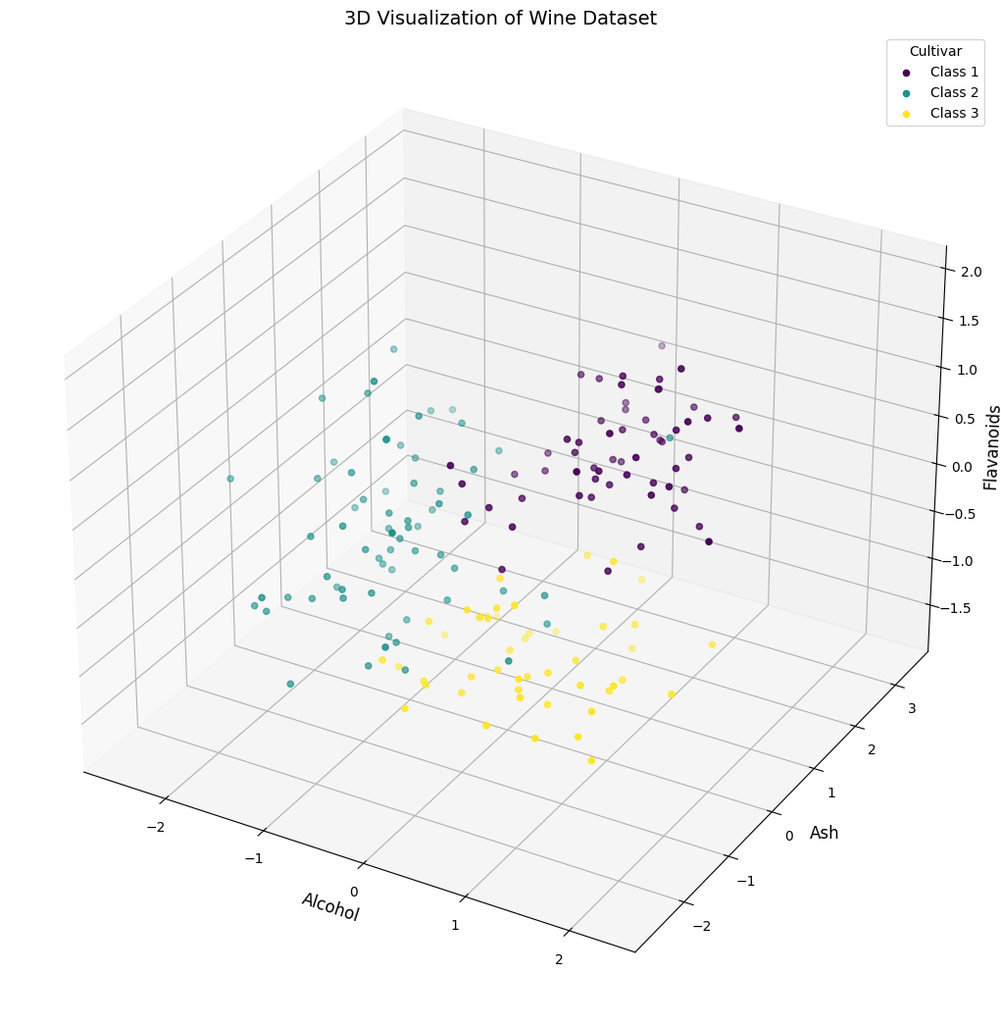

```python
import matplotlib.pyplot as plt

top_features = selected_features[:3]
X_top = wine_new[top_features]
y = wine_new['Cultivar']

fig = plt.figure(figsize=(13, 13))
ax = fig.add_subplot(111, projection='3d')

unique_classes = y.unique()
colors = plt.cm.get_cmap('viridis', len(unique_classes))

for i, class_label in enumerate(unique_classes):
    ax.scatter(X_top[y == class_label].iloc[:, 0],
               X_top[y == class_label].iloc[:, 1],
               X_top[y == class_label].iloc[:, 2],
               label=f'Class {class_label}',
               color=colors(i))

ax.set_xlabel(top_features[0], fontsize=12)
ax.set_ylabel(top_features[1], fontsize=12)
ax.set_zlabel(top_features[2], fontsize=12)
ax.set_title('3D Visualization of Wine Dataset', fontsize=14)
ax.legend(title='Cultivar')
plt.show()
```

6. Разбейте набор данных на обучающую и тестовую выборки. Создайте и обучите классификатор на основе деревьев решений с глубиной дерева не более 4, определите долю верных ответов на тестовой выборке и визуализируйте границу принятия решений и построенное дерево решений. При визуализации границы принятия решений используйте два признака с наиболее высокой оценкой важности.

Разделила данные на обучающую и тестовую выборки.

```python
from sklearn.model_selection import train_test_split

X = wine_new[top_features[:2]]
y = wine_new['Cultivar']

X_train, X_test, y_train, y_test = train_test_split(X, y, test_size=0.2, random_state=42, stratify=y)
X_train.shape, y_train.shape, X_test.shape, y_test.shape
```

```
((136, 2), (136,), (35, 2), (35,))
```

Создала и перешла к обучению классификатора на основе деревьев решений. Оценила точности на тестовой выборке.

```python
from sklearn.metrics import accuracy_score
from sklearn.tree import DecisionTreeClassifier, plot_tree

dt_classifier = DecisionTreeClassifier(max_depth=4, random_state=42)
dt_classifier.fit(X_train, y_train)

# Оценка точности на тестовой выборке
y_pred = dt_classifier.predict(X_test)
accuracy = accuracy_score(y_test, y_pred)
print(f"Accuracy on test set: {accuracy:.2f}")
```

```
Accuracy on test set: 0.77
```

Визуализировала границы принятия решений.

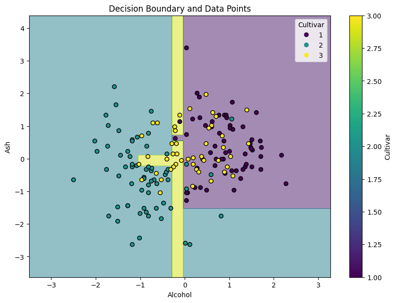

```python
x_min, x_max = X[selected_features[0]].min() - 1, X[selected_features[0]].max() + 1
y_min, y_max = X[selected_features[1]].min() - 1, X[selected_features[1]].max() + 1
xx, yy = np.meshgrid(np.arange(x_min, x_max, 0.01), np.arange(y_min, y_max, 0.01))

Z = dt_classifier.predict(np.c_[xx.ravel(), yy.ravel()])
Z = Z.reshape(xx.shape)

plt.figure(figsize=(10, 7))
plt.contourf(xx, yy, Z, alpha=0.5, cmap='viridis')

scatter = plt.scatter(X[selected_features[0]], X[selected_features[1]], c=y, edgecolors='k', cmap='viridis', label='Classes')

plt.xlabel(selected_features[0])
plt.ylabel(selected_features[1])
plt.title('Decision Boundary and Data Points')
plt.colorbar(scatter, label='Cultivar')
plt.legend(*scatter.legend_elements(), title='Cultivar')
plt.show()
```

Визуализировала дерево решений.

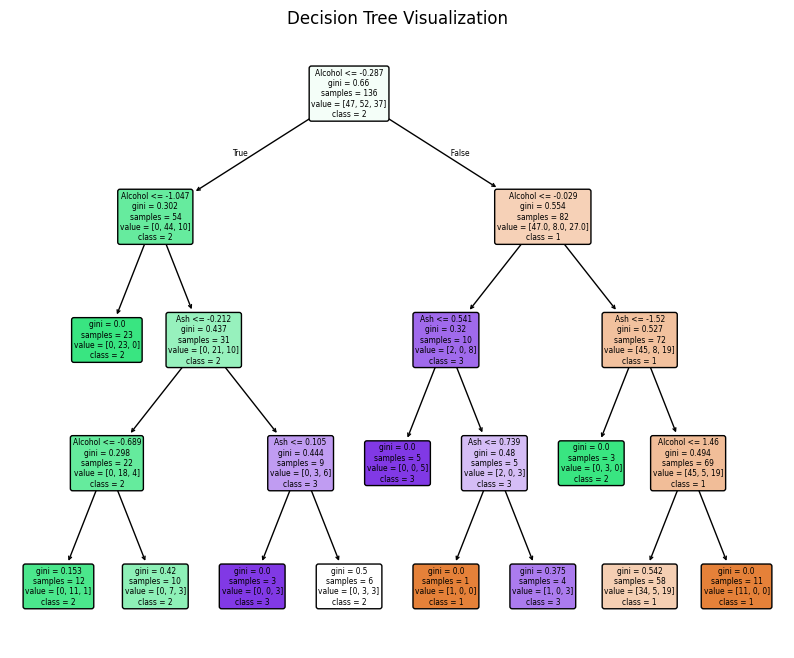

```python
plt.figure(figsize=(10, 8))
plot_tree(dt_classifier, filled=True, feature_names=top_features[:2], class_names=y.unique().astype(str), rounded=True)
plt.title('Decision Tree Visualization')
plt.show()
```

Дополнительные базовые классификаторы:

классификатор логистической регрессии с полиномиальной зависимостью (degree=2)

классификатор метода опорных векторов

Комбинированный классификатор: VotingClassifier

Ансамблевые классификаторы: RandomForestClassifier, GradientBoostingClassifier

Показатель качества модели – доля верных ответов (accuracy)

```python
from sklearn.linear_model import LogisticRegression
from sklearn.preprocessing import PolynomialFeatures
from sklearn.pipeline import make_pipeline
from sklearn.svm import SVC

# Классификатор логистической регрессии с полиномиальной зависимостью
poly_classifier = make_pipeline(PolynomialFeatures(degree=2), LogisticRegression(max_iter=1000))
poly_classifier.fit(X_train, y_train)

# Классификатор метода опорных векторов
svm_classifier = SVC(probability=True)
svm_classifier.fit(X_train, y_train)

classifiers = [poly_classifier, svm_classifier, dt_classifier]
classifier_names = ['Logistic Regression (Poly)', 'SVM', 'Decision Tree']

for clf, name in zip(classifiers, classifier_names):
    y_pred = clf.predict(X_test)
    accuracy = accuracy_score(y_test, y_pred)
    print(f'Accuracy of {name}: {accuracy:.2f}')
```

```
Accuracy of Logistic Regression (Poly): 0.86
Accuracy of SVM: 0.80
Accuracy of Decision Tree: 0.77
```

```python
from sklearn.ensemble import VotingClassifier, RandomForestClassifier, GradientBoostingClassifier

# Создаем VotingClassifier
voting_classifier = VotingClassifier(
    estimators=[
        ('log_reg_poly', poly_classifier),
        ('svm', svm_classifier),
        ('dt', dt_classifier),
    ],
    voting='soft'
)

# Обучение комбинированного классификатора
voting_classifier.fit(X_train, y_train)
y_pred_voting = voting_classifier.predict(X_test)
accuracy_voting = accuracy_score(y_test, y_pred_voting)
print(f'Accuracy of Voting Classifier: {accuracy_voting:.2f}')
```

```
Accuracy of Voting Classifier: 0.83
```

8. Постройте и обучите пару ансамблевых классификаторов, указанных в индивидуальном задании, и сравните их производительность по показателю, указанному в индивидуальном задании.

Сравнила производительность.

```python
rf_classifier = RandomForestClassifier(random_state=42)
rf_classifier.fit(X_train, y_train)
y_pred_rf = rf_classifier.predict(X_test)
accuracy_rf = accuracy_score(y_test, y_pred_rf)
print(f'Accuracy of Random Forest Classifier: {accuracy_rf:.2f}')

gb_classifier = GradientBoostingClassifier(random_state=42)
gb_classifier.fit(X_train, y_train)
y_pred_gb = gb_classifier.predict(X_test)
accuracy_gb = accuracy_score(y_test, y_pred_gb)
print(f'Accuracy of Gradient Boosting Classifier: {accuracy_gb:.2f}')
```

```
Accuracy of Random Forest Classifier: 0.74
Accuracy of Gradient Boosting Classifier: 0.69
```

9. Постройте границы принятия решений ансамблевых классификаторов с визуализацией точек набора данных разных классов разными цветами. Подпишите оси и рисунок.

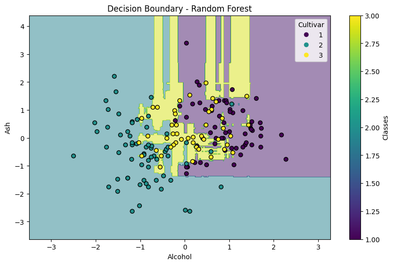

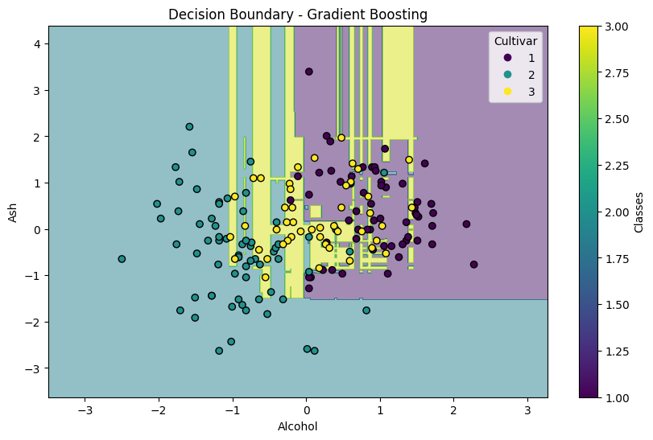

```python
x_min, x_max = X[top_features[0]].min() - 1, X[top_features[0]].max() + 1
y_min, y_max = X[top_features[1]].min() - 1, X[top_features[1]].max() + 1
xx, yy = np.meshgrid(np.arange(x_min, x_max, 0.01), np.arange(y_min, y_max, 0.01))

Z_rf = rf_classifier.predict(np.c_[xx.ravel(), yy.ravel()])
Z_rf = Z_rf.reshape(xx.shape)

Z_gb = gb_classifier.predict(np.c_[xx.ravel(), yy.ravel()])
Z_gb = Z_gb.reshape(xx.shape)

plt.figure(figsize=(10, 6))
plt.contourf(xx, yy, Z_rf, alpha=0.5, cmap='viridis')

scatter_rf = plt.scatter(X[top_features[0]], X[top_features[1]], c=y, edgecolors='k', cmap='viridis', label='Classes')
plt.xlabel(top_features[0])
plt.ylabel(top_features[1])
plt.title('Decision Boundary - Random Forest')
plt.colorbar(scatter_rf, label='Classes')
plt.legend(*scatter_rf.legend_elements(), title='Cultivar')
plt.show()

plt.figure(figsize=(10, 6))
plt.contourf(xx, yy, Z_gb, alpha=0.5, cmap='viridis')

scatter_gb = plt.scatter(X[top_features[0]], X[top_features[1]], c=y, edgecolors='k', cmap='viridis', label='Classes')
plt.xlabel(top_features[0])
plt.ylabel(top_features[1])
plt.title('Decision Boundary - Gradient Boosting')
plt.colorbar(scatter_gb, label='Classes')
plt.legend(*scatter_gb.legend_elements(), title='Cultivar')
plt.show()
```